# 5: Extracting future farm temperatures

FAO Climate Change Risks to Fed Mariculture

Author

Tormey Reimer

Published

11 June 2026

← Previous: Check species: Atlantic salmon

Next: Home →

# Overview

Once farm locations are assigned, temperatures need to be extracted into the future.

# Get farm locations

**Load saved data for summarising**

```r
assigned_farms <- file.path(prepdata_path, "assigned_farms.qs") %>%
  qd_read()
```

## Correcting temperatures

Bias correction uses the decadal mean from 2015–2024 for both datasets (`data-prep-scripts/correcting-temperatures.R`). The change in temperature per grid cell from the CMIP projections is used as a delta applied on top of the contemporary NASA SST data (i.e. `corrected = CMIP_future − CMIP_meanyear + NASA_meanyear`). February 29 dates in leap years are handled by interpolating the adjacent meanyear layers (DOY 059 and DOY 060) with equal weights. The corrected rasters are saved to `bigdata_path/ESGF/EC-Earth3P-HR/projected_adjusted/`.

# Extract farm temperatures

**List the projected_adjusted files to check we’re getting them from the correct place**

```r
tos_rast_fnms <- file.path(bigdata_path, "ESGF", "EC-Earth3P-HR", "projected_adjusted") %>%
  list.files(full.names = T) %>%
  sort()

# Use just one raster for cell assignment
tos_rast <- rast(tos_rast_fnms[1])
```

Once we have the corrected global temperature rasters, we can extract the locations we actually want - the farms that have been assigned for use in this analysis. The first step is to assign each farm location a cell number (or several cell numbers) within the temperature raster stack.

**Assign cell(s) to each farm and create a lookup table for future temperature extraction**

```r
farm_points <- assigned_farms %>%
  vect()

# Attempt to extract the cell numbers dirrectly underneath assigned farms
farm_cells <- terra::extract(tos_rast, farm_points, cells = T, ID = F) %>%
  rename(focal_cell = cell)
farm_cells$farm_ID <- farm_points$farm_ID

simple_assigned <- farm_cells %>%
  filter(!is.na(focal_mean))

message(sprintf("%i of %i farm IDs have a simple cell extracted (%0.1f%%).",
  nrow(simple_assigned),
  nrow(farm_cells),
  100*nrow(simple_assigned)/nrow(farm_cells)
))
```

```
11888 of 15922 farm IDs have a simple cell extracted (74.7%).
```

**Assign cell(s) to each farm and create a lookup table for future temperature extraction**

```r
# Look at the 4 surrounding cells of each missing cell to try and find a viable temperature
still_missing_1 <- farm_cells %>%
  filter(is.na(focal_mean))

neighbours_4 <- terra::adjacent(tos_rast, cells = still_missing_1$focal_cell, directions = 4)
neighbours_4 <- split(neighbours_4, row(neighbours_4)) |> unname()

still_missing_1 <- still_missing_1 %>%
  mutate(neighbours_4 = neighbours_4, new_cells = NA)

still_missing_1 <- still_missing_1 %>%
  mutate(
    new_cells = lapply(neighbours_4, function(nb) {
      cells <- unlist(nb)
      temps <- terra::extract(tos_rast, cells)
      if (any(!is.na(temps$focal_mean))) cells else NA
    })
  )

assigned_4 <- still_missing_1 %>%
  filter(!is.na(new_cells))

message(sprintf("%i of %i remaining farm IDs have cells from the 4 cardinal directions around extracted (%0.1f%%).",
  nrow(assigned_4),
  nrow(still_missing_1),
  100*nrow(assigned_4)/nrow(still_missing_1))
)
```

```
3152 of 4034 remaining farm IDs have cells from the 4 cardinal directions around extracted (78.1%).
```

**Assign cell(s) to each farm and create a lookup table for future temperature extraction**

```r
# Look at the 8 surrounding cells of each missing cell to try and find a viable temperature
still_missing_2 <- still_missing_1 %>%
  filter(is.na(new_cells))

neighbours_8 <- terra::adjacent(tos_rast, cells = still_missing_2$focal_cell, directions = 8)
neighbours_8 <- split(neighbours_8, row(neighbours_8)) |> unname()

still_missing_2 <- still_missing_2 %>%
  mutate(neighbours_8 = neighbours_8)

still_missing_2 <- still_missing_2 %>%
  mutate(
    new_cells = lapply(neighbours_8, function(nb) {
      cells <- unlist(nb)
      temps <- terra::extract(tos_rast, cells)
      if (any(!is.na(temps$focal_mean))) cells else NA
    })
  )

assigned_8 <- still_missing_2 %>%
  filter(!is.na(new_cells))

message(sprintf("%i of %i remaining farm IDs have cells from the 8 directions around extracted (%0.1f%%).",
  nrow(assigned_8),
  nrow(still_missing_2),
  100*nrow(assigned_8)/nrow(still_missing_2)
))
```

```
331 of 882 remaining farm IDs have cells from the 8 directions around extracted (37.5%).
```

**Assign cell(s) to each farm and create a lookup table for future temperature extraction**

```r
# Let's expand the search
still_missing_3 <- still_missing_2 %>%
  filter(is.na(new_cells))

still_missing_3 <- still_missing_3 %>%
  mutate(
    new_cells = lapply(neighbours_4, function(nb) {
      nb_all <- terra::adjacent(tos_rast, cells = nb, directions = 8) %>% as.vector() %>% unique()
      nb_all <- terra::adjacent(tos_rast, cells = nb_all, directions = 4) %>% as.vector() %>% unique()
      temps <- terra::extract(tos_rast, nb_all)
      if (any(!is.na(temps$focal_mean))) nb_all else NA
    })
  )

assigned_exp <- still_missing_3 %>%
  filter(!is.na(new_cells))

message(sprintf("%i of %i remaining farm IDs have cells from the expanded cell radius around extracted (%0.1f%%).",
  nrow(assigned_exp),
  nrow(still_missing_3),
  100*nrow(assigned_exp)/nrow(still_missing_3))
)
```

```
414 of 551 remaining farm IDs have cells from the expanded cell radius around extracted (75.1%).
```

**Assign cell(s) to each farm and create a lookup table for future temperature extraction**

```r
message(sprintf("There are %i farm_IDs still remaining.", still_missing_3 %>% filter(is.na(new_cells)) %>% nrow()))
```

```
There are 137 farm_IDs still remaining.
```

After 4 rounds of searching progressively wider areas, there are still 137 farms missing temperatures. Where are they?

**Show the missing farms and their nearest neighbour**

```
<SpatRaster> resampled to 5e+05 cells.
```

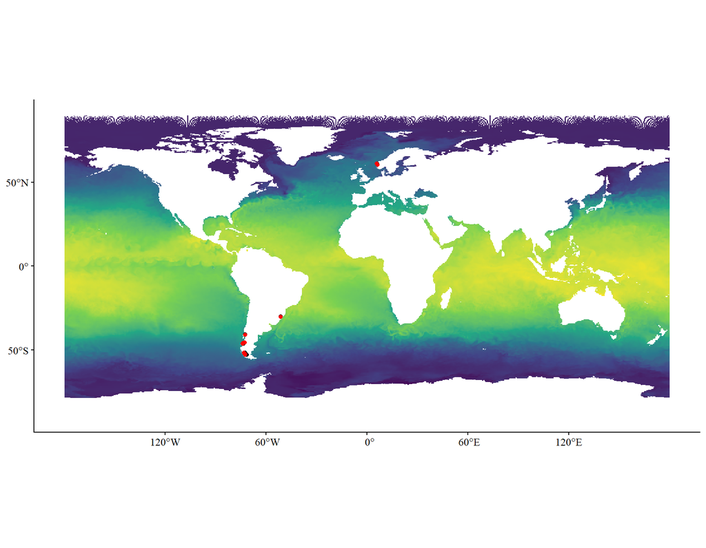

Figure 1

```r
missing_farms <- still_missing_3 %>%
  filter(is.na(new_cells)) %>%
  pull(farm_ID)

farm_points_missing <- assigned_farms %>% # includes a geometry column
  mutate(is_missing = case_when(farm_ID %in% missing_farms ~ T, T ~ F)) %>%
  select(farm_ID, is_missing) %>%
  mutate(type = "missing")

missing <- farm_points_missing %>% filter(is_missing)
non_missing <- farm_points_missing %>% filter(!is_missing)

nearest_idx <- sf::st_nearest_feature(missing, non_missing)
nearst_non_missing <- non_missing[nearest_idx, ] %>%
  mutate(type = "nonmissing")

paired <- rbind(missing, nearst_non_missing)
duplicated <- cbind(
  st_drop_geometry(missing),
  nearst_non_missing %>% st_drop_geometry() %>% rename(dup_farm_ID = farm_ID) %>% select(dup_farm_ID)
) %>%
  select(farm_ID, dup_farm_ID)

ggplot() +
  geom_spatraster(data = tos_rast) +
  geom_sf(data = paired, aes(geometry = geometry, colour = as.factor(type))) +
  scale_fill_viridis_c(na.value = NA) +
  scale_color_manual(values = c("missing" = "black", "nonmissing" = "red")) +
  prettyplot() + coord_sf()
```

The missing farms are mostly a little bit inland of the coast (up estuaries, etc) so they’re not being well-captured by SST changes. However, they’re extremely close to non-missing points of data, so we’ll be copying those temperatures for those features.

**Combine cell assignments**

```r
# The simple assignments
assigned_farms_cells <- assigned_farms %>%
  left_join(
    simple_assigned %>%
      mutate(focal_cells = as.list(focal_cell)) %>%
      select(focal_cells, farm_ID),
    by = "farm_ID"
  )

# The 4-way assignments
geometry <- sf::st_geometry(assigned_farms_cells) # so annoying
assigned_farms_cells <- assigned_farms_cells %>%
  sf::st_drop_geometry() %>%
  rows_update(
    assigned_4 %>%
      select(farm_ID, new_cells) %>%
      rename(focal_cells = new_cells),
    by = "farm_ID"
  ) %>%
  sf::st_set_geometry(geometry)

# The 8-way assignments
geometry <- sf::st_geometry(assigned_farms_cells) # so annoying
assigned_farms_cells <- assigned_farms_cells %>%
  sf::st_drop_geometry() %>%
  rows_update(
    assigned_8 %>%
      select(farm_ID, new_cells) %>%
      rename(focal_cells = new_cells),
    by = "farm_ID"
  ) %>%
  sf::st_set_geometry(geometry)

# The expanded assignments
geometry <- sf::st_geometry(assigned_farms_cells) # so annoying
assigned_farms_cells <- assigned_farms_cells %>%
  sf::st_drop_geometry() %>%
  rows_update(
    assigned_exp %>%
      select(farm_ID, new_cells) %>%
      rename(focal_cells = new_cells),
    by = "farm_ID"
  ) %>%
  sf::st_set_geometry(geometry)

# The ones copying from neighbours
geometry <- sf::st_geometry(assigned_farms_cells) # so annoying
assigned_farms_cells <- assigned_farms_cells %>%
  sf::st_drop_geometry() %>%
  rows_update(
    duplicated %>% mutate(focal_cells = as.list(as.numeric(dup_farm_ID))) %>% select(farm_ID, focal_cells),
    by = "farm_ID"
  ) %>%
  sf::st_set_geometry(geometry)

# Finally check for any missing - should be none!
assigned_farms_cells %>%
  filter(length(focal_cells) == 0)
```

```
Simple feature collection with 0 features and 11 fields
Geometry type: POINT
Bounding box:  xmin: NA ymin: NA xmax: NA ymax: NA
Geodetic CRS:  WGS 84
# A tibble: 0 × 12
# ℹ 12 variables: ISO3_Code <chr>, country <chr>, species_group <chr>,
#   farm_ID <dbl>, F_CODE <dbl>, source <chr>, model_name <chr>,
#   prod_perfarm <dbl>, value <dbl>, n_farms <int>, focal_cells <list>,
#   geometry <POINT [°]>
```

**Combine cell assignments**

```r
qd_save(assigned_farms_cells, file.path(prepdata_path, "assigned_farms_focal_cells.qs"))
```

**Prep for temperature extraction**

```r
# quick cleanup
rm(geometry, cmip_meanyear_100, nasa_meanyear_100, still_missing_2, still_missing_3, assigned_4, assigned_8, assigned_exp, simple_assigned, farm_points_missing, non_missing, missing, paired, duplicated, still_missing_1, nearst_non_missing)
```

**Prep for temperature extraction**

```r
gc()
```

```
          used  (Mb) gc trigger  (Mb) max used  (Mb)
Ncells 3006898 160.6    5168517 276.1  4269657 228.1
Vcells 9576487  73.1   34449110 262.9 34442513 262.8
```

**Prep for temperature extraction**

```r
# Where to save?
farm_temp_outputs <- file.path(prepdata_path, "farm_temps")
dir.create(farm_temp_outputs, showWarnings = F)

# Group the projected-adjusted temperature raster files by year
tos_rast_fnms_ls <- tibble(
  path = tos_rast_fnms,
  date = as.Date(str_extract(basename(tos_rast_fnms), "\\d{4}-\\d{2}-\\d{2}")),
  year = year(date)
)
tos_rast_fnms_ls <- split(tos_rast_fnms_ls, tos_rast_fnms_ls$year)
```

**Extract all farms for each year, accumulating results into some lookup files**

```r
# yr_fnms <- tos_rast_fnms_ls[[1]]
walk(
  tos_rast_fnms_ls,
  function(yr_fnms) {
    tos_stack <- rast(yr_fnms$path)
    names(tos_stack) <- yr_fnms$date

    # Extract ALL cells needed across all farms in one call
    all_cells <- unique(unlist(assigned_farms_cells$focal_cells))
    extracted <- terra::extract(tos_stack, all_cells)  # one extract for all farms

    # Label rows with cell number for lookup
    extracted$cell <- all_cells

    # Save the year's extracted data as a lookup table
    qs2::qs_save(
      extracted,
      file.path(prepdata_path, "temp_lookup_files", paste0("extracted_", unique(yr_fnms$year), ".qs"))
    )
  },
  .progress = TRUE
)
```

**Assemble per-farm files from the lookup tables and extracted temperatures**

```r
assigned_farms_cells <- qd_read(file.path(prepdata_path, "assigned_farms_focal_cells.qs"))
subset_farms <- assigned_farms_cells %>%
  filter(source == "extracted") %>%
  pull(farm_ID) %>% unique()

# id <- unique(assigned_farms_cells$farm_ID)[1]
walk(
  subset_farms,
  function(id) {
    out_file <- file.path(farm_temp_outputs, paste0("farm_", fix_int(id, digits = 8), ".qs"))
    # if (!file.exists(out_file)) {
      cells <- assigned_farms_cells$focal_cells[assigned_farms_cells$farm_ID == id][[1]]

      # f <- list.files(file.path(prepdata_path, "temp_lookup_files"), pattern = "extracted_\\d{4}\\.qs", full.names = TRUE)[1]
      temps <- map_dfr(
        list.files(file.path(prepdata_path, "temp_lookup_files"), pattern = "extracted_\\d{4}\\.qs", full.names = TRUE),
        function(f) {
          extracted <- f %>%
            qs2::qs_read() %>%
            filter(cell %in% cells) %>%
            select(-cell)

          vals <- colMeans(as.matrix(extracted), na.rm = TRUE)

          data.frame(
            date = as.Date(names(extracted)),
            sst = unname(vals)
          )
        }
      ) %>%
        mutate(farm_ID = id)
      qs2::qs_save(temps, out_file)
    # }
  },
  .progress = TRUE
)
```

**Save farm temperatures by model names - this will make it easier to load for production model loading**

```r
model_names <- unique(assigned_farms$model_name)

# mn <- model_names[11]
walk(
  model_names,
  function (mn) {
    model_farms <- assigned_farms %>%
      filter(model_name == mn)

    temps <- file.path(farm_temp_outputs) %>%
      list.files(full.names = T) %>%
      str_subset(paste0(fix_int(model_farms$farm_ID, 8), collapse = "|")) %>%
      map_dfr(qs_read)

    model_farms <- model_farms %>%
      left_join(temps, by = join_by(farm_ID)) %>%
      mutate(year = year(date) %>% as.factor())

    qs2::qs_save(model_farms, file.path(prepdata_path, "farm_temps_bymodel", paste0("farm_temps_", mn, ".qs")))
  },
  .progress = T
)
```

[output not shown]

[output not shown]

[output not shown]

[output not shown]

[output not shown]

[output not shown]

[output not shown]

[output not shown]

[output not shown]

[output not shown]

[output not shown]

[output not shown]

[output not shown]

[output not shown]

[output not shown]

**Plot farm temperatures by country - mostly just to show how it changes over time**

```r
ISO_Codes <- unique(assigned_farms$ISO3_Code)

# iso <- ISO_Codes[11]
walk(
  ISO_Codes,
  function (iso) {
    country_farms <- assigned_farms %>%
      filter(ISO3_Code == iso)

    temps <- file.path(farm_temp_outputs) %>%
      list.files(full.names = T) %>%
      str_subset(paste0(fix_int(country_farms$farm_ID, 8), collapse = "|")) %>%
      map_dfr(qs_read)

    country_farms <- country_farms %>%
      left_join(temps, by = join_by(farm_ID)) %>%
      mutate(year = year(date) %>% as.factor())

    p <- ggplot(country_farms, aes(x = year, y = sst, fill = model_name)) +
      geom_boxplot() +
      theme_classic() +
      facet_wrap(~model_name, ncol = 1) +
      theme(axis.text.x = element_text(angle = 90))

    ggsave(
      plot = p,
      filename = file.path(outs_path, "plots", "farm_temperatures", paste0("farm_temps_", iso, ".png")),
      dpi = 300,
      width = 10,
      height = 2.5 * max(ggplot_build(p)$layout$layout$ROW) + 1
    )
  },
  .progress = T
)
```

[output not shown]

[output not shown]

[output not shown]

[output not shown]

[output not shown]

[output not shown]

[output not shown]

[output not shown]

[output not shown]

[output not shown]

[output not shown]

[output not shown]

[output not shown]

[output not shown]

[output not shown]

[output not shown]

[output not shown]

[output not shown]

[output not shown]

[output not shown]

[output not shown]

[output not shown]

[output not shown]

[output not shown]

[output not shown]

[output not shown]

[output not shown]

[output not shown]

[output not shown]

[output not shown]

[output not shown]

[output not shown]

[output not shown]

[output not shown]

[output not shown]

[output not shown]

[output not shown]

[output not shown]

[output not shown]

[output not shown]

[output not shown]

[output not shown]

[output not shown]

[output not shown]

[output not shown]

[output not shown]

[output not shown]

[output not shown]

[output not shown]

[output not shown]

[output not shown]

[output not shown]

[output not shown]

[output not shown]

[output not shown]

[output not shown]

[output not shown]

[output not shown]

[output not shown]

[output not shown]

[output not shown]

[output not shown]

[output not shown]

[output not shown]

[output not shown]

[output not shown]

[output not shown]

[output not shown]

[output not shown]

[output not shown]

[output not shown]

[output not shown]

[output not shown]

[output not shown]

[output not shown]

[output not shown]

[output not shown]

[output not shown]

[output not shown]

[output not shown]

[output not shown]

[output not shown]

[output not shown]

[output not shown]

[output not shown]

[output not shown]

[output not shown]

[output not shown]